# es() - Exponential Smoothing

Ivan Svetunkov

2019-12-10

`es()` is a part of smooth package. It allows constructing Exponential Smoothing (also known as ETS), selecting the most appropriate one among 30 possible ones, including exogenous variables and many more.

In this vignette we will use data from `Mcomp` package, so it is advised to install it. We also use some of the functions of the `greybox` package.

Let’s load the necessary packages:

```r
require(smooth)
require(greybox)
require(Mcomp)
```

You may note that `Mcomp` depends on `forecast` package and if you load both `forecast` and `smooth`, then you will have a message that `forecast()` function is masked from the environment. There is nothing to be worried about - `smooth` uses this function for consistency purposes and has exactly the same original `forecast()` as in the `forecast` package. The inclusion of this function in `smooth` was done only in order not to include `forecast` in dependencies of the package.

The simplest call of this function is:

```r
es(M3$N2457$x, h=18, holdout=TRUE, silent=FALSE)
```

```
## Forming the pool of models based on... ANN, ANA, AAN, Estimation progress:    100%... Done!
```

```
## Time elapsed: 0.57 seconds
## Model estimated: ETS(MNN)
## Persistence vector g:
##  alpha
## 0.1452
## Initial values were optimised.
##
## Loss function type: MSE; Loss function value: 0.1653
## Error standard deviation: 0.4129
## Sample size: 97
## Number of estimated parameters: 3
## Number of degrees of freedom: 94
## Information criteria:
##      AIC     AICc      BIC     BICc
## 1645.978 1646.236 1653.702 1654.292
##
## Forecast errors:
## MPE: 26.3%; sCE: -1919.1%; Bias: 86.9%; MAPE: 39.8%
## MASE: 2.944; sMAE: 120.1%; sMSE: 242.7%; rMAE: 1.258; rRMSE: 1.367
```

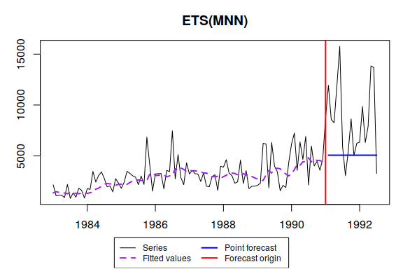

In this case function uses branch and bound algorithm to form a pool of models to check and after that constructs a model with the lowest information criterion. As we can see, it also produces an output with brief information about the model, which contains:

1. How much time was elapsed for the model construction;
2. What type of ETS was selected;
3. Values of persistence vector (smoothing parameters);
4. What type of initialisation was used;
5. How many parameters were estimated (standard deviation is included);
6. Standard deviation of residuals. The model has multiplicative error term, so as a result the standard deviation is small.
7. Cost function type and the value of that cost function;
8. Information criteria for this model;
9. Forecast errors (because we have set `holdout=TRUE`).

The function has also produced a graph with actual values, fitted values and point forecasts.

If we need prediction interval, then we run:

```r
es(M3$N2457$x, h=18, holdout=TRUE, interval=TRUE, silent=FALSE)
```

```
## Forming the pool of models based on... ANN, ANA, AAN, Estimation progress:    100%... Done!
```

```
## Time elapsed: 0.44 seconds
## Model estimated: ETS(MNN)
## Persistence vector g:
##  alpha
## 0.1452
## Initial values were optimised.
##
## Loss function type: MSE; Loss function value: 0.1653
## Error standard deviation: 0.4129
## Sample size: 97
## Number of estimated parameters: 3
## Number of degrees of freedom: 94
## Information criteria:
##      AIC     AICc      BIC     BICc
## 1645.978 1646.236 1653.702 1654.292
##
## 95% parametric prediction interval was constructed
## 72% of values are in the prediction interval
## Forecast errors:
## MPE: 26.3%; sCE: -1919.1%; Bias: 86.9%; MAPE: 39.8%
## MASE: 2.944; sMAE: 120.1%; sMSE: 242.7%; rMAE: 1.258; rRMSE: 1.367
```

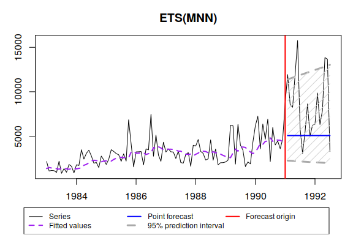

Due to multiplicative nature of error term in the model, the interval are asymmetric. This is the expected behaviour. The other thing to note is that the output now also provides the theoretical width of prediction interval and its actual coverage.

If we save the model (and let’s say we want it to work silently):

```r
ourModel <- es(M3$N2457$x, h=18, holdout=TRUE, silent="all")
```

we can then reuse it for different purposes:

```r
es(M3$N2457$x, model=ourModel, h=18, holdout=FALSE, interval="np", level=0.93)
```

```
## Time elapsed: 0.05 seconds
## Model estimated: ETS(MNN)
## Persistence vector g:
##  alpha
## 0.1452
## Initial values were provided by user.
##
## Loss function type: MSE; Loss function value: 0.1838
## Error standard deviation: 0.4306
## Sample size: 115
## Number of estimated parameters: 1
## Number of provided parameters: 2
## Number of degrees of freedom: 114
## Information criteria:
##      AIC     AICc      BIC     BICc
## 1994.861 1994.897 1997.606 1997.690
##
## 93% nonparametric prediction interval was constructed
```

We can also extract the type of model in order to reuse it later:

```r
modelType(ourModel)
```

```
## [1] "MNN"
```

This handy function, by the way, also works with ets() from forecast package.

If we need actual values from the model, we can use `actuals()` method from `greybox` package:

```r
actuals(ourModel)
```

```
##         Jan    Feb    Mar    Apr    May    Jun    Jul    Aug    Sep    Oct
## 1983 2158.1 1086.4 1154.7 1125.6  920.0 2188.6  829.2 1353.1  947.2 1816.8
## 1984 1783.3 1713.1 3479.7 2429.4 3074.3 3427.4 2783.7 1968.7 2045.6 1471.3
## 1985 1821.0 2409.8 3485.8 3289.2 3048.3 2914.1 2173.9 3018.4 2200.1 6844.3
## 1986 3238.9 3252.2 3278.8 1766.8 3572.8 3467.6 7464.7 2748.4 5126.7 2870.8
## 1987 3220.7 3586.0 3249.5 3222.5 2488.5 3332.4 2036.1 1968.2 2967.2 3151.6
## 1988 3894.1 4625.5 3291.7 3065.6 2316.5 2453.4 4582.8 2291.2 3555.5 1785.0
## 1989 2102.9 2307.7 6242.1 6170.5 1863.5 6318.9 3992.8 3435.1 1585.8 2106.8
## 1990 6168.0 7247.4 3579.7 6365.2 4658.9 6911.8 2143.7 5973.9 4017.2 4473.0
## 1991 8749.1
##         Nov    Dec
## 1983 1624.5  868.5
## 1984 2763.7 2328.4
## 1985 4160.4 1548.8
## 1986 2170.2 4326.8
## 1987 1610.5 3985.0
## 1988 2020.0 2026.8
## 1989 1892.1 4310.6
## 1990 3591.9 4676.5
## 1991
```

We can then use persistence or initials only from the model to construct the other one:

```r
es(M3$N2457$x, model=modelType(ourModel), h=18, holdout=FALSE, initial=ourModel$initial, silent="graph")
```

```
## Time elapsed: 0.02 seconds
## Model estimated: ETS(MNN)
## Persistence vector g:
##  alpha
## 0.1509
## Initial values were provided by user.
##
## Loss function type: MSE; Loss function value: 0.1838
## Error standard deviation: 0.4324
## Sample size: 115
## Number of estimated parameters: 2
## Number of provided parameters: 1
## Number of degrees of freedom: 113
## Information criteria:
##      AIC     AICc      BIC     BICc
## 1996.845 1996.952 2002.334 2002.589
```

```r
es(M3$N2457$x, model=modelType(ourModel), h=18, holdout=FALSE, persistence=ourModel$persistence, silent="graph")
```

```
## Time elapsed: 0.02 seconds
## Model estimated: ETS(MNN)
## Persistence vector g:
##  alpha
## 0.1452
## Initial values were optimised.
##
## Loss function type: MSE; Loss function value: 0.1838
## Error standard deviation: 0.4325
## Sample size: 115
## Number of estimated parameters: 2
## Number of provided parameters: 1
## Number of degrees of freedom: 113
## Information criteria:
##      AIC     AICc      BIC     BICc
## 1996.861 1996.968 2002.351 2002.605
```

or provide some arbitrary values:

```r
es(M3$N2457$x, model=modelType(ourModel), h=18, holdout=FALSE, initial=1500, silent="graph")
```

```
## Time elapsed: 0.02 seconds
## Model estimated: ETS(MNN)
## Persistence vector g:
##  alpha
## 0.1498
## Initial values were provided by user.
##
## Loss function type: MSE; Loss function value: 0.184
## Error standard deviation: 0.4328
## Sample size: 115
## Number of estimated parameters: 2
## Number of provided parameters: 1
## Number of degrees of freedom: 113
## Information criteria:
##      AIC     AICc      BIC     BICc
## 1997.028 1997.136 2002.518 2002.773
```

Using some other parameters may lead to completely different model and forecasts:

```r
es(M3$N2457$x, h=18, holdout=TRUE, loss="aTMSE", bounds="a", ic="BIC", interval=TRUE)
```

```
## Time elapsed: 0.46 seconds
## Model estimated: ETS(ANN)
## Persistence vector g:
##  alpha
## 0.0798
## Initial values were optimised.
##
## Loss function type: aTMSE; Loss function value: 39565651.9
## Error standard deviation: 1466.912
## Sample size: 97
## Number of estimated parameters: 3
## Number of degrees of freedom: 94
## Information criteria:
##      AIC     AICc      BIC     BICc
## 1974.076 1974.736 1985.865 1986.455
##
## 95% parametric prediction interval was constructed
## 44% of values are in the prediction interval
## Forecast errors:
## MPE: 33.4%; sCE: -2196.8%; Bias: 90.4%; MAPE: 43.4%
## MASE: 3.235; sMAE: 132%; sMSE: 278%; rMAE: 1.382; rRMSE: 1.463
```

You can play around with all the available parameters to see what’s their effect on final model.

In order to combine forecasts we need to use “C” letter:

```r
es(M3$N2457$x, model="CCN", h=18, holdout=TRUE, silent="graph")
```

```
## Estimation progress:    10%20%30%40%50%60%70%80%90%100%... Done!
```

```
## Time elapsed: 0.75 seconds
## Model estimated: ETS(CCN)
## Initial values were optimised.
##
## Loss function type: MSE
## Error standard deviation: 1404.465
## Sample size: 97
## Information criteria:
## (combined values)
##      AIC     AICc      BIC     BICc
## 1646.545 1646.941 1654.794 1655.304
##
## Forecast errors:
## MPE: 27.4%; sCE: -1963.2%; Bias: 88.2%; MAPE: 40.4%
## MASE: 2.992; sMAE: 122.1%; sMSE: 248.5%; rMAE: 1.278; rRMSE: 1.383
```

Model selection from a specified pool and forecasts combination are called using respectively:

```r
es(M3$N2457$x, model=c("ANN","AAN","AAdN","ANA","AAA","AAdA"), h=18, holdout=TRUE, silent="graph")
```

```
## Estimation progress:    17%33%50%67%83%100%... Done!
```

```
## Time elapsed: 0.9 seconds
## Model estimated: ETS(ANN)
## Persistence vector g:
##  alpha
## 0.1582
## Initial values were optimised.
##
## Loss function type: MSE; Loss function value: 2007704.5316
## Error standard deviation: 1439.368
## Sample size: 97
## Number of estimated parameters: 3
## Number of degrees of freedom: 94
## Information criteria:
##      AIC     AICc      BIC     BICc
## 1688.987 1689.245 1696.711 1697.301
##
## Forecast errors:
## MPE: 25.3%; sCE: -1880.4%; Bias: 86%; MAPE: 39.4%
## MASE: 2.909; sMAE: 118.7%; sMSE: 238.1%; rMAE: 1.243; rRMSE: 1.354
```

```r
es(M3$N2457$x, model=c("CCC","ANN","AAN","AAdN","ANA","AAA","AAdA"), h=18, holdout=TRUE, silent="graph")
```

```
## Estimation progress:    17%33%50%67%83%100%... Done!
```

```
## Time elapsed: 0.8 seconds
## Model estimated: ETS(CCC)
## Initial values were optimised.
##
## Loss function type: MSE
## Error standard deviation: 1386.675
## Sample size: 97
## Information criteria:
## (combined values)
##      AIC     AICc      BIC     BICc
## 1689.864 1690.147 1696.984 1697.488
##
## Forecast errors:
## MPE: 17.1%; sCE: -1568.3%; Bias: 77.7%; MAPE: 37.3%
## MASE: 2.658; sMAE: 108.4%; sMSE: 206.7%; rMAE: 1.135; rRMSE: 1.261
```

Now let’s introduce some artificial exogenous variables:

```r
x <- cbind(rnorm(length(M3$N2457$x),50,3),rnorm(length(M3$N2457$x),100,7))
```

and fit a model with all the exogenous first:

```r
es(M3$N2457$x, model="ZZZ", h=18, holdout=TRUE, xreg=x)
```

```
## Time elapsed: 1.79 seconds
## Model estimated: ETSX(MAN)
## Persistence vector g:
##  alpha   beta
## 0.1062 0.0000
## Initial values were optimised.
## Xreg coefficients were estimated in a normal style
##
## Loss function type: MSE; Loss function value: 0.1614
## Error standard deviation: 0.4147
## Sample size: 97
## Number of estimated parameters: 6
## Number of provided parameters: 1
## Number of degrees of freedom: 91
## Information criteria:
##      AIC     AICc      BIC     BICc
## 1649.473 1650.610 1665.125 1667.260
##
## Forecast errors:
## MPE: 25.2%; sCE: -1849.7%; Bias: 88%; MAPE: 37.6%
## MASE: 2.822; sMAE: 115.1%; sMSE: 230.5%; rMAE: 1.205; rRMSE: 1.332
```

or construct a model with selected exogenous (based on IC):

```r
es(M3$N2457$x, model="ZZZ", h=18, holdout=TRUE, xreg=x, xregDo="select")
```

```
## Time elapsed: 0.83 seconds
## Model estimated: ETS(MNN)
## Persistence vector g:
##  alpha
## 0.1452
## Initial values were optimised.
##
## Loss function type: MSE; Loss function value: 0.1653
## Error standard deviation: 0.4129
## Sample size: 97
## Number of estimated parameters: 3
## Number of degrees of freedom: 94
## Information criteria:
##      AIC     AICc      BIC     BICc
## 1645.978 1646.236 1653.702 1654.292
##
## Forecast errors:
## MPE: 26.3%; sCE: -1919.1%; Bias: 86.9%; MAPE: 39.8%
## MASE: 2.944; sMAE: 120.1%; sMSE: 242.7%; rMAE: 1.258; rRMSE: 1.367
```

or the one with the updated xreg:

```r
ourModel <- es(M3$N2457$x, model="ZZZ", h=18, holdout=TRUE, xreg=x, updateX=TRUE)
```

If we want to check if lagged x can be used for forecasting purposes, we can use `xregExpander()` function from `greybox` package:

```r
es(M3$N2457$x, model="ZZZ", h=18, holdout=TRUE, xreg=xregExpander(x), xregDo="select")
```

```
## Time elapsed: 1.48 seconds
## Model estimated: ETSX(MNN)
## Persistence vector g:
##  alpha
## 0.1574
## Initial values were optimised.
## Xreg coefficients were estimated in a normal style
##
## Loss function type: MSE; Loss function value: 0.1541
## Error standard deviation: 0.4009
## Sample size: 97
## Number of estimated parameters: 4
## Number of degrees of freedom: 93
## Information criteria:
##      AIC     AICc      BIC     BICc
## 1641.184 1641.618 1651.483 1652.477
##
## Forecast errors:
## MPE: 26%; sCE: -1902.8%; Bias: 84.3%; MAPE: 40.6%
## MASE: 2.971; sMAE: 121.2%; sMSE: 240.8%; rMAE: 1.269; rRMSE: 1.361
```

If we are confused about the type of estimated model, the function `formula()` will help us:

```r
formula(ourModel)
```

```
## [1] "y[t] = (l[t-1] + b[t-1]) * exp(a1[t-1] * x1[t] + a2[t-1] * x2[t]) * e[t]"
```

A feature available since 2.1.0 is fitting `ets()` model and then using its parameters in `es()`:

```r
etsModel <- forecast::ets(M3$N2457$x)
esModel <- es(M3$N2457$x, model=etsModel, h=18)
```

The point forecasts in the majority of cases should the same, but the prediction interval may be different (especially if error term is multiplicative):

```r
forecast(etsModel,h=18,level=0.95)
```

```
##          Point Forecast       Lo 95    Hi 95
## Aug 1992       8523.456   853.30277 16193.61
## Sep 1992       8563.040   719.69262 16406.39
## Oct 1992       8602.625   587.42532 16617.82
## Nov 1992       8642.209   456.39433 16828.02
## Dec 1992       8681.794   326.50223 17037.09
## Jan 1993       8721.379   197.65965 17245.10
## Feb 1993       8760.963    69.78442 17452.14
## Mar 1993       8800.548   -57.19924 17658.29
## Apr 1993       8840.132  -183.36139 17863.63
## May 1993       8879.717  -308.76695 18068.20
## Jun 1993       8919.302  -433.47621 18272.08
## Jul 1993       8958.886  -557.54529 18475.32
## Aug 1993       8998.471  -681.02653 18677.97
## Sep 1993       9038.055  -803.96882 18880.08
## Oct 1993       9077.640  -926.41794 19081.70
## Nov 1993       9117.225 -1048.41679 19282.87
## Dec 1993       9156.809 -1170.00570 19483.62
## Jan 1994       9196.394 -1291.22258 19684.01
```

```r
forecast(esModel,h=18,level=0.95)
```

```
##          Point forecast Lower bound (2.5%) Upper bound (97.5%)
## Aug 1992       9365.350           3643.844            19986.94
## Sep 1992       9559.549           3669.680            20528.18
## Oct 1992       9775.371           3685.081            21370.51
## Nov 1992       9965.262           3716.345            21955.13
## Dec 1992      10190.608           3720.829            22826.86
## Jan 1993      10419.506           3763.111            23607.54
## Feb 1993      10607.835           3760.669            24241.29
## Mar 1993      10850.312           3791.112            24971.33
## Apr 1993      11068.715           3819.934            25845.59
## May 1993      11314.857           3828.231            26572.88
## Jun 1993      11556.210           3862.500            27445.51
## Jul 1993      11799.603           3904.668            28228.03
## Aug 1993      12040.241           3907.743            29195.55
## Sep 1993      12311.305           3918.998            30177.42
## Oct 1993      12542.486           3979.255            30988.84
## Nov 1993      12799.176           3977.299            31937.16
## Dec 1993      13052.249           4010.490            32403.25
## Jan 1994      13328.293           4009.003            33745.87
```

Finally, if you work with M or M3 data, and need to test a function on a specific time series, you can use the following simplified call:

```r
es(M3$N2457, interval=TRUE, silent=FALSE)
```

```
## Forming the pool of models based on... ANN, ANA, AAN, Estimation progress:    40%50%60%70%80%90%100%... Done!
```

```
## Time elapsed: 2.52 seconds
## Model estimated: ETS(MAN)
## Persistence vector g:
##  alpha   beta
## 0.1165 0.0000
## Initial values were optimised.
##
## Loss function type: MSE; Loss function value: 0.1811
## Error standard deviation: 0.4331
## Sample size: 115
## Number of estimated parameters: 4
## Number of provided parameters: 1
## Number of degrees of freedom: 111
## Information criteria:
##      AIC     AICc      BIC     BICc
## 1999.144 1999.508 2010.124 2010.986
##
## 95% parametric prediction interval was constructed
## 50% of values are in the prediction interval
## Forecast errors:
## MPE: -188.1%; sCE: 2504.6%; Bias: -99.3%; MAPE: 188.2%
## MASE: 3.396; sMAE: 139.3%; sMSE: 243.9%; rMAE: 2.825; rRMSE: 2.306
```

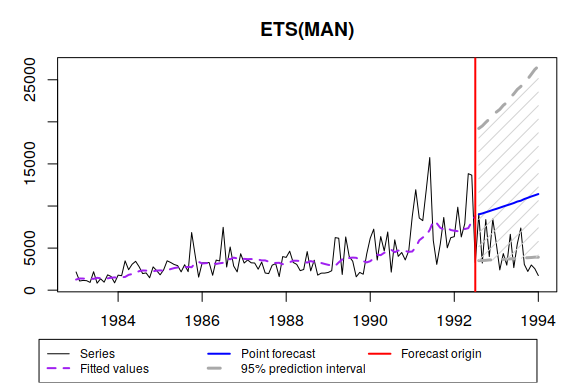

This command has taken the data, split it into in-sample and holdout and produced the forecast of appropriate length to the holdout.